# Distribuições de probabilidade complementares - Distribuição Beta

Maria Carolina Pacheco

## 1 Introdução

Vou usar dados de eficiência fotossintética (YII) de corais da espécie *Siderastrea stellata*. Esse dado é uma taxa que varia entre 0 e 1, indicando a eficiência com que o aparato fotossintético está utilizando a luz que chega nele.

Esses dados foram obtidos por meio de um experimento em laboratório. Parte dos corais foi submetida a ao aquecimento da água do mar até 32°C, enquanto a outra parte permaneceu em temperatura ideal de 27°C durante todo o experimento. Além disso, alguns corais foram coletados no topo e outros na base do recife.

Assim, temos:

- Variável resposta: YII
- Variáveis preditoras: tratamento (aquecido x controle); habitat (topo x base); dias de experimento

Abrindo os dados:

```r
#abrir meu banco de dados
micro_sid <- read.csv("dados_scriptsR/geral_microhabitat_sid.csv", header = T, sep =";", dec = ".")

#começar a explorar os dados
str(micro_sid)
```

```
## 'data.frame':    1351 obs. of  13 variables:
##  $ data       : chr  "09/12/2024" "09/12/2024" "09/12/2024" "09/12/2024" ...
##  $ dia_exp    : int  0 0 0 0 0 0 0 0 0 0 ...
##  $ temp       : num  27.7 27.7 27.7 27.7 27.7 ...
##  $ temp_excess: num  0 0 0 0 0 0 0 0 0 0 ...
##  $ dhw        : num  0 0 0 0 0 0 0 0 0 0 ...
##  $ trat       : chr  "C" "C" "C" "C" ...
##  $ sist       : int  1 1 1 1 1 1 2 2 2 2 ...
##  $ id         : chr  "TA1" "BK1" "TC1" "TE1" ...
##  $ yii        : num  0.653 0.64 0.669 0.644 0.623 0.657 0.668 0.712 0.714 0.63 ...
##  $ cor        : chr  "D5" "D5" "D4" "D4" ...
##  $ habitat    : chr  "T" "B" "T" "T" ...
##  $ colonia    : chr  "A" "K" "C" "E" ...
##  $ fragmento  : chr  "A1" "K1" "C1" "E1" ...
```

```r
#converter em fator o que está como character
cols1 <- c("trat", "id", "cor", "habitat", "colonia", "fragmento")
micro_sid[, cols1] <- lapply(micro_sid[, cols1], factor)

#definir a ordem dos níveis dos meus fatores
micro_sid$trat <- factor(micro_sid$trat, levels = c("C","A"))
micro_sid$habitat <- factor(micro_sid$habitat, levels = c("T", "B"))
```

## 2 Explorando os dados visualmente

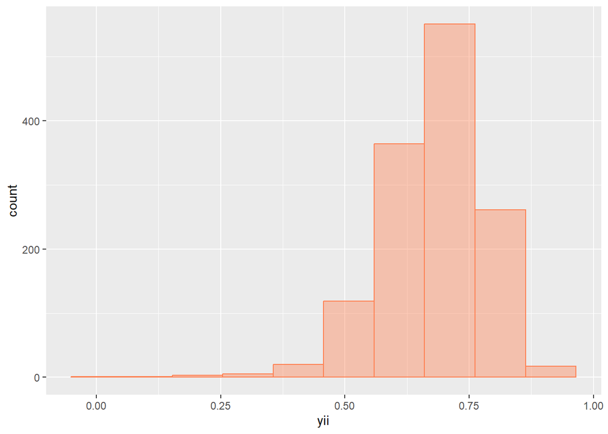

```r
#visualizando a distribuição da variável resposta
ggplot(micro_sid, aes(x = yii)) +
  geom_histogram(fill = 'coral',col = 'coral', alpha = 0.4,
                 bins = 10)
```

Os dados parecem ter um leve desvio à esquerda.

Visualizando agora os dados por tratamento e habitat:

```
## No summary function supplied, defaulting to `mean_se()`
```

```
## No summary function supplied, defaulting to `mean_se()`
```

```
## No summary function supplied, defaulting to `mean_se()`
```

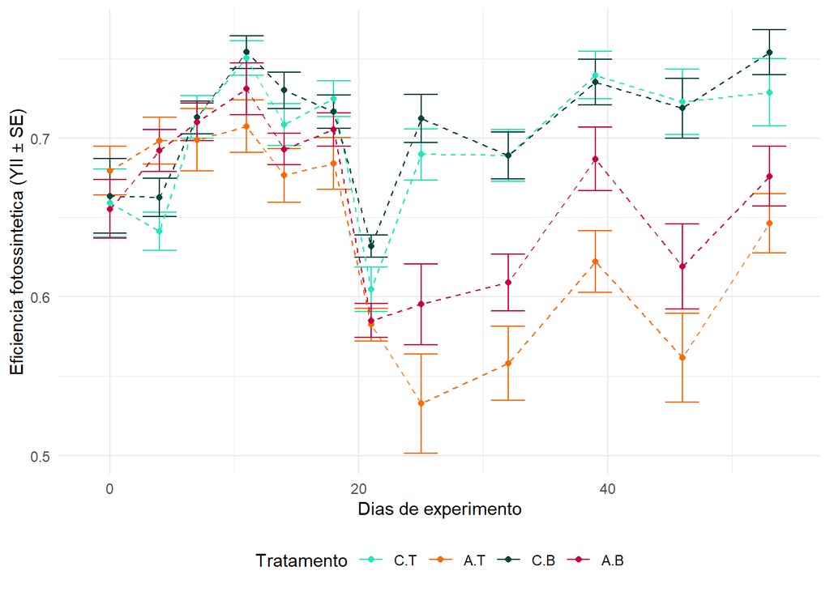

```r
ggplot(micro_sid, aes(y=yii, x=dia_exp, color=interaction(trat, habitat), group=interaction(trat, habitat)))+
  stat_summary(geom="errorbar")+
  stat_summary(geom = "line", linetype=2)+
  stat_summary(geom = "point")+
  xlab("Dias de experimento")+
  ylab("Eficiencia fotossintetica (YII ± SE)")+
  theme_minimal()+
  theme(legend.position="bottom")+
  scale_color_manual(values=c("#25e4bc","#f96a00","#03453d","#c7003f"), name="Tratamento")
```

No gráfico vemos que a eficiência fotossintética parece diferir entre os corais que foram submetidos ao aquecimento (A, linhas laranja e rosa) e os que permaneceram na temperatura ideal (C, linhas azuis. Quanto ao habitat, parece ter havido uma leve diferenciação entre topo e base somente após o 20° dia de experimento.

## 3 Modelo

Vou começar ajustando os zeros pros dados ficarem entre 0 e 1

```r
#Ajustar os zeros pra poder usar betareg

summary(micro_sid$yii)
```

```
##    Min. 1st Qu.  Median    Mean 3rd Qu.    Max.    NA's
##  0.0000  0.6180  0.6890  0.6795  0.7480  0.9140       9
```

```r
micro_sid$yii <- (micro_sid$yii + (median(micro_sid$yii, na.rm = TRUE)*0.1))
```

Agora vamos testar diferentes formas de fazer o modelo. Vou começar mais simples, mas depois vou aproveitar estou usando uma função que aceita modelos mistos e vou colocar o ID dos corais como fator aleatório, já que tenho medidas repetidas.

```r
#Modelo 1: testar o efeito do tratamento com o tempo pra ver se o experimento funcionou
mod_beta1 <- glmmTMB(yii ~ trat + dia_exp,
                     family=beta_family(link="logit"),
                     data=micro_sid)

#Modelo 2: agora vendo se teve diferença entre habitats
mod_beta2 <- glmmTMB (yii ~ trat + dia_exp + habitat,
                      family = beta_family(link="logit"),
                      data = micro_sid)

#Modelo 3: vou aproveitar que essa funçao aceita modelos mistos e vou colocar o id dos fragmentos como fator aleatorio
mod_beta3 <- glmmTMB (yii ~ trat + dia_exp + habitat +
                      (1|id), #porque tenho medidas repetidas
                      family = beta_family(link="logit"),
                      data = micro_sid)
#Modelo 4: testar agora com interaçao
mod_beta4 <- glmmTMB (yii ~ trat*dia_exp*habitat +
                        (1|id),
                      family = beta_family(link="logit"),
                      data = micro_sid)
# Agora comparar tudo com AIC

AIC(mod_beta1, mod_beta2, mod_beta3, mod_beta4)
```

```
##           df       AIC
## mod_beta1  4 -2481.415
## mod_beta2  5 -2487.320
## mod_beta3  6 -2529.464
## mod_beta4 10 -2588.307
```

O modelo que parece mais bem ajustado (teve o menor AIC) é o 4, com o efeito aleatório e as interações. Agora vamos checar o ajuste do modelo:

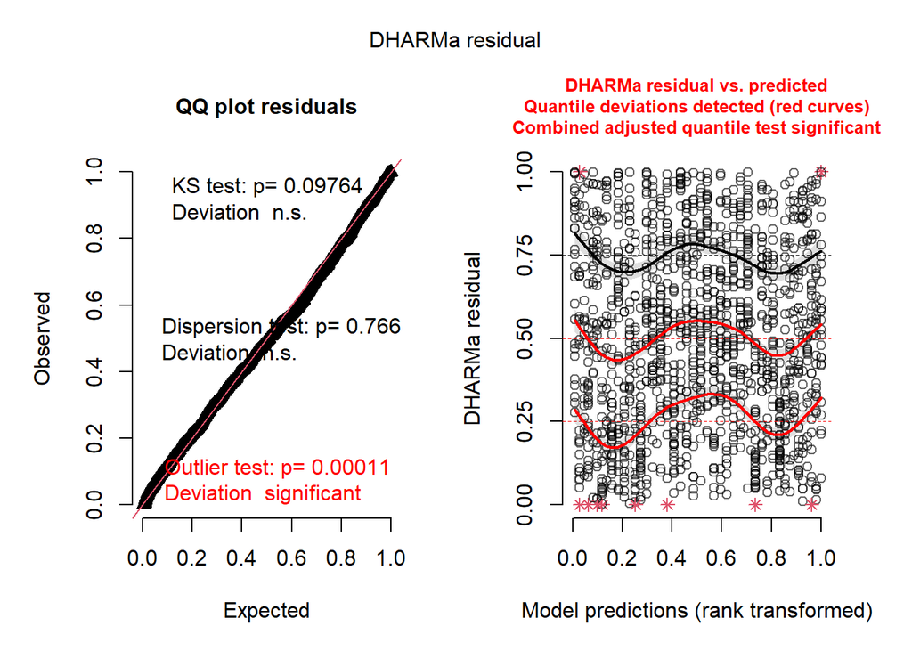

```r
#checando o ajuste do modelo visualmente
simres_mod4 <- simulateResiduals(mod_beta4, n=1000) # simular os resíduos
plot(simres_mod4)
```

```r
check_model(simres_mod4)
```

```
## `check_outliers()` does not yet support models of class `glmmTMB`.
```

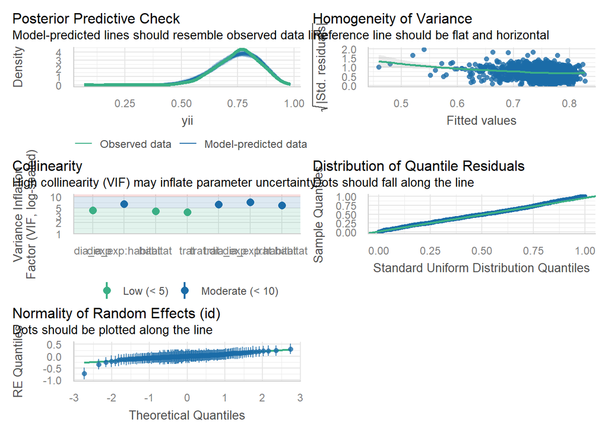

Usando o pacote DHARMA não está parecendo bem ajustado, mas pela função check_model parece quase bom. O grafico da homogeneidade de variancia ainda não ta muito reto e horizontal. Será que eu devia rodar um GAM?

### 3.1 Interpretando os resultados

```r
summary(mod_beta4)
```

```
##  Family: beta  ( logit )
## Formula:          yii ~ trat * dia_exp * habitat + (1 | id)
## Data: micro_sid
##
##       AIC       BIC    logLik -2*log(L)  df.resid
##   -2588.3   -2536.3    1304.2   -2608.3      1332
##
## Random effects:
##
## Conditional model:
##  Groups Name        Variance Std.Dev.
##  id     (Intercept) 0.02572  0.1604
## Number of obs: 1342, groups:  id, 161
##
## Dispersion parameter for beta family (): 21.7
##
## Conditional model:
##                          Estimate Std. Error z value Pr(>|z|)
## (Intercept)             1.0901489  0.0534630  20.391  < 2e-16 ***
## tratA                   0.0851503  0.0741460   1.148   0.2508
## dia_exp                 0.0046368  0.0018158   2.554   0.0107 *
## habitatB                0.0432422  0.0757611   0.571   0.5682
## tratA:dia_exp          -0.0161683  0.0024429  -6.619 3.63e-11 ***
## tratA:habitatB         -0.0325970  0.1055639  -0.309   0.7575
## dia_exp:habitatB        0.0001078  0.0025800   0.042   0.9667
## tratA:dia_exp:habitatB  0.0048634  0.0034955   1.391   0.1641
## ---
## Signif. codes:  0 '***' 0.001 '**' 0.01 '*' 0.05 '.' 0.1 ' ' 1
```

- O modelo mostrou que tem efeito da interação entre tratamento e tempo
- Mostra que o aquecido teve diminuição do eficiência fotossintética com o aumento dos dias de experimento
- Não teve efeito do habitat

### 3.2 Visualizando esses resultados

```r
pred <- ggpredict(mod_beta4, terms = c("dia_exp", "trat","habitat"))
```

```
## You are calculating adjusted predictions on the population-level (i.e.
##   `type = "fixed"`) for a *generalized* linear mixed model.
##   This may produce biased estimates due to Jensen's inequality. Consider
##   setting `bias_correction = TRUE` to correct for this bias.
##   See also the documentation of the `bias_correction` argument.
```

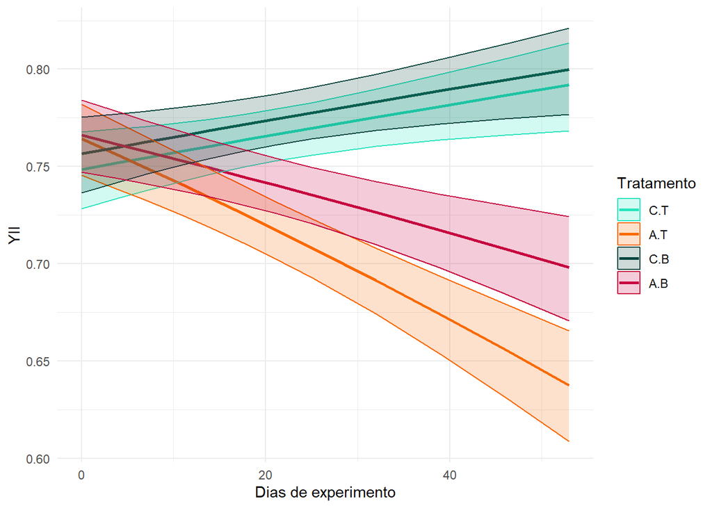

```r
View(pred)

ggplot(pred, aes(x = x, y = predicted, fill = interaction(group, facet), color=interaction(group, facet), group=interaction(group, facet))) +
  geom_line(size = 1) +
  geom_ribbon(aes(ymin = conf.low, ymax = conf.high), alpha = 0.2) +
  labs(x = "Dias de experimento", y = "YII") +
  scale_color_manual(values=c("#25e4bc","#f96a00","#03453d","#c7003f"), name="Tratamento")+
  scale_fill_manual(values=c("#25e4bc","#f96a00","#03453d","#c7003f"), name="Tratamento")+
  theme_minimal()
```

Esse gráfico mostra os valores preditos pelo modelo. Os azuis são controle e as cores quentes são o aquecido. Podemos ver a diminuição da eficiência fotossintética dos corais do tratamento aquecido ao longo do tempo.